# AgWise Remote Sensing Module

Payel Gosh, Louise Leroux, Amit Srivastava, Meklit Chernet

2024-08-19

### **1. The data architecture**

#### Agwise’s remote sensing module employs a comprehensive methodology, beginning with the download of satellite MODIS NDVI images and ending with its pre-processing and analysis in order to obtain (1) Planting and harvesting dates and (2) Crop type suitability maps.

#### The AgWise Remote Sensing Module scripts and outputs are hosted in:

- Input preparation scripts are hosted in: **agwise datasourcing/dataops/datasourcing**
- Geospatial analytics scripts are hosted in: **agwise-datasourcing/dataops/agwise-potentialyield**

#### Similar to the other AgWise modules, the remote sensing module has a separate space for ** Data and Script**

- **agwise-datasourcing/dataops/datasourcing/Script**
- **agwise-datasourcing/dataops/datasourcing/Data**
- **agwise-potentialyield/dataops/potentialyield/Script**
- **agwise-potentialyield/dataops/potentialyield/Data**

#### **1.1 The Script** folder has two sub folders:

- **agwise-datasourcing/dataops/datasourcing/Script/generic**
- **agwise-datasourcing/dataops/datasourcing/Script/useCases**
- **agwise-potentialyield/dataops/potentialyield/Script/generic**
- **agwise-potentialyield/dataops/potentialyield/Script/useCases**

generic folder : contains generalized scripts while the instances of running the generic scripts for specific country, use case and crop combinations is host in the later. For example:**~/agwise-datasourcing/dataops/datasourcing/Scripts/generic/get_MODISdata.R** is the source script which can be used for downloading MODIS NDVI data for any region of Interest.

useCases folder :In this system, for every country, use case and crop combinations, a unique folder is created to host all the data sourcing scripts run for it and this is implemented in a standard way across all AgWise modules.For example, scripts in **~/agwise-datasourcing/dataops/datasourcing/Scripts/useCases/useCase_Rwanda_RAB/get_MODISdata_useCase_Rwanda_RAB.R** is run to get MODIS NDVI data of a particular year for the RAB use case in Rwanda.

### **2. The data flow**

##### In every AgWise module and for every country, use case, and crop combinations, the following structure is used (shown with examples):

- **raw**
  - The downloaded unprocessed NDVI data are saved in the **MODISdata/raw/NDVI** folder. Please note that since the unprocessed NDVI data can be used for every type of crop, the data are stored at the useCase level.
  - e.g., **~/agwise-datasourcing/dataops/datasourcing/Data/useCase_Rwanda_RAB/MODISdata/raw/NDVI/**
  - for season wise crop coordinates data and planting and harvesting date to be used as an input in crop type probability mapping. They are saved in **raw/**.
  - e.g., **~/agwise-datacuration/dataops/datacuration/Data/useCase_Rwanda_RAB/Maize/raw/data4RS.RDS**
- **transform**
  - contains intermediate results of processing data.
  - e.g., **~/agwise-datasourcing/dataops/datasourcing/Data/useCase_Rwanda_RAB/MODISdata/transform/NDVI**
- **result**
  - The model outputs are saved in the **result/**
  - e.g., **~/agwise-potentialyield/dataops/potentialyield/Data/useCase_Rwanda_RAB/Maize/result**

##### **Note:Phenology extraction and crop type probability mapping can be done only after downloading and pre processing the satellite data following the data sourcing steps**

```
Make sure the scripts are run in the following order:
```

- for downloading the data access **get_MODISdata.R** in agwise-datasourcing folder , e.g., **~/agwise-datasourcing/dataops/datasourcing/Scripts/generic/get_MODISdata.R**
- for downloading Crop mask through GEE refer to **get_ESACropland_fromGEE.html** in **~/agwise-datasourcing/dataops/datasourcing/Scripts/generic/**
- for pre-processing the data for any data gap access **get_MODISts_PreProc.R** in agwise-datasourcing folder , e.g., **~/agwise-datasourcing/dataops/datasourcing/Scripts/generic/get_MODISts_PreProc.R**
- for crop type probability access **get_RS_Croptype.R** in agwise-potentialyield folder, e.g., **~/agwise-potentialyield/dataops/potentialyield/Script/generic/RemoteSensing/get_RS_Croptype.R**. NOTA this step is optional, in case there is no ground data or not enough ground data to calibrate the crop type probability model, the following step (phenology extraction) can be run on the crop mask only (from GEE).
- for phenology extraction access **get_RS_Phenology.R** in agwise-potentialyield folder , e.g., **~/agwise-potentialyield/dataops/potentialyield/Script/generic/RemoteSensing/get_RS_Phenology.R**

The general Remote Sensing module workflow is presented in the figure below:

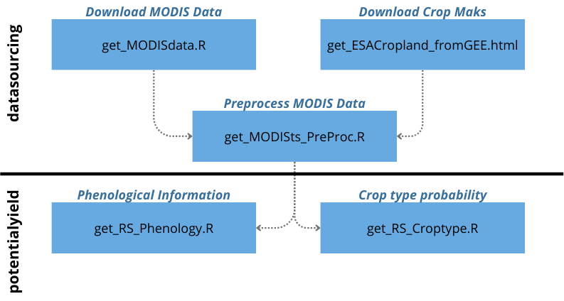

Remote Sensing module workflow.

### **3. Steps to download and preprocess satellite data (eg:useCase_Rwanda_RAB)**

3.1. For input preparation part create a folder under *agwise-datasourcing/dataops/datasourcing/Script/useCases* …. In this folder you will have the scripts to execute remote sensing functions for the initial processing of your use case - for example, **~/agwise-datasourcing/dataops/datasourcing/Scripts/useCases/useCase_Rwanda_RAB/** (use the relevant useCase country usecaseName )

3.2. Download the crop mask from GEE and place it in a **CropMask** folder of useCase, under the folder *MODISdata/raw/* for example, **~/agwise-datasourcing/dataops/datasourcing/Data/useCase_Rwanda_RAB/MODISdata/raw/CropMask/Cropmask_Rwn250m.tif**

3.3. Copy the scripts

- **get_MODISdata_useCase_Rwanda_RAB.R** - this script sources -**get_MODISdata.R**which downloads the MODIS NDVI Satellite data.
- **get_MODISts_PreProc_useCase_Rwanda_RAB.R** - this script sources -**get_MODISts_PreProc.R** which smoothens the data to fill any gaps from **agwise-datasourcing/dataops/datasourcing/Script/useCases/useCase_Rwanda_RAB/** to the folder you just created at step 3.1.

3.4. Fill in the correct arguments in the script you copied, i.e., **get_MODISdata_useCase_Rwanda_RAB.R and get_MODISts_PreProc_useCase_Rwanda_RAB.R** in your newly created folder: - change the country,level,admin_unit_name ,use case name, planting year, harvest year, etc. For deeper understanding of the different arguments please refer to the documentation in *get_MODISdata.R and get_MODISts_PreProc.R*.

### **4. Steps to extract crop type probability (eg:useCase_Rwanda_RAB)**

4.3. Fill in the correct arguments in the script you copied, i.e., **get_RS_Croptype_useCase_Rwanda_RAB.R** in your newly created folder: - change the country, use case name, planting year,planting month, harvest year,harvest month etc. For deeper understanding of the different arguments please refer to the documentation in *get_RS_Croptype.R*.

**IMPORTANT** : The ground data containing the GPS location of the crop type data must follow specific format : (1)- Should be a .RDS file, (2) Should contain at least 5 columns : ‘lon’ (longitude data), ‘lat’ (latitude data), ‘planting_date’ (planting date data in the **Dates format** YYYY-mm-dd), ‘harvest_date’ (harvest date data in the **Dates format** YYYY-mm-dd), and ‘crop’ (the type of crop). An example is provide in **~/agwise-potentialyield/dataops/potentialyield/Script/useCases/useCase_Rwanda_RAB/Maize/raw/data4RS.RDS**.

### **5. Steps to extract phenological characteristics (eg:useCase_Rwanda_RAB)**

5.1. For analysis create a folder under *agwise-potentialyield/dataops/potentialyield/Script/useCases* …. In this folder you will have the scripts to execute remote sensing functions for the initial processing of your use case - for example, **~/agwise-potentialyield/dataops/potentialyield/Script/useCases/useCase_Rwanda_RAB/** (use the relevant useCase country usecaseName )

**IMPORTANT** : The ground data containing the GPS location of the planting dates data must follow specific format : (1)- Should be a .RDS file, (2) Should contain at least 5 columns : ‘lon’ (longitude data), ‘lat’ (latitude data), ‘planting_date’ (planting date data in the **Dates format** YYYY-mm-dd), ‘harvest_date’ (harvest date data in the **Dates format** YYYY-mm-dd), and ‘crop’ (the type of crop). An example is provide in **~/agwise-potentialyield/dataops/potentialyield/Script/useCases/useCase_Rwanda_RAB/Maize/raw/data4RS.RDS**.

#### Making use of the generic function for specific use case is demonstrated below.

```
#################################################################################################################
## source "get_MODISdata.R" function and execute it for Rwanda RAB use case
#################################################################################################################

source("~/agwise-datasourcing/dataops/datasourcing/Scripts/generic/get_MODISdata.R")
download_MODIS(country = "Rwanda", useCaseName = "RAB",level=0, admin_unit_name = NULL, Start_year = 2021, End_year = 2022, overwrite = TRUE)

#################################################################################################################
## source "get_MODISts_PreProc.R" function and execute it for Rwanda RAB use case
#################################################################################################################

source("~/agwise-datasourcing/dataops/datasourcing/Scripts/generic/get_MODISts_PreProc.R")
smooth_rasterTS(country = "Rwanda", useCaseName = "RAB",Planting_year = 2021, Harvesting_year = 2022, overwrite = TRUE, CropMask=TRUE)

#################################################################################################################
## source "get_RS_Croptype.R" functions and execute it for Rwanda RAB Maize use case
#################################################################################################################

source("~/agwise-potentialyield/dataops/potentialyield/Script/generic/RemoteSensing/get_RS_Croptype.R")

country = "Rwanda"
useCaseName = "RAB"
level = 1
admin_unit_name = NULL
Planting_year = 2021
Harvesting_year = 2022
Planting_month = "September"
Harvesting_month = "June"
overwrite = TRUE
crop = c("Maize")
coord = c("lon", "lat")
CropMask = FALSE

CropType (country, useCaseName, level, admin_unit_name, Planting_year, Harvesting_year, Planting_month, Harvesting_month, crop, coord, overwrite, CropMask)

#################################################################################################################
## source "get_RS_Phenology.R" function and execute it for Rwanda RAB use case
#################################################################################################################

source("~/agwise-potentialyield/dataops/potentialyield/Script/generic/RemoteSensing/get_RS_Phenology.R")

country = "Rwanda"
useCaseName = "RAB"
level = 1
admin_unit_name = NULL
crop= "Maize"
Planting_year = 2021
Harvesting_year = 2022
Planting_month = "September"
Harvesting_month = "March"
emergence = 5
overwrite = TRUE
CropMask = TRUE
CropType = TRUE
thr= c(0.50, 0.30)
validation = TRUE
coord = c('lon', 'lat')

Phenology_rasterTS(country, useCaseName, crop, level, admin_unit_name, Planting_year, Harvesting_year, Planting_month, Harvesting_month,
                   emergence, CropMask=T, CropType=T, coord, thr=c(0.50,0.30), validation=T, overwrite)
```